# Title DSCI 8950 - Data Science Capstone

# Individual EDA - Group - B - NILESH PURNEKAR

## Step 1 - Project Context & Research Question

This individual EDA focuses on the relationship between socioeconomic status and student absenteeism in Nebraska public school districts during the 2020–2021 school year. Socioeconomic status is approximated using the percentage of students eligible for Free & Reduced Lunch (FRL%), a commonly used poverty proxy in education research.

**Research questions:**

1. How is FRL% distributed across districts in Nebraska?
2. How is chronic absenteeism distributed across districts?
3. Is higher FRL% associated with higher absenteeism/chronic absenteeism?
4. Do patterns differ when comparing elementary vs secondary school contexts?
5. What is the relationship between FRL% and chronic absenteeism rate at the school level (and is there a visible trend/pattern)?

## Step 2 — Data Sources

1. **Free & Reduced Lunch Counts by School (2020–2021)**  
   Contains school-level enrollment counts and FRL counts. District-level FRL% was created by aggregating school-level counts.
2. **Student Absences Counts by District (2020–2021)**  
   Contains district-level absence metrics, including measures related to chronic absenteeism.
3. **Free & Reduced Lunch Counts by District (2020–2021)**  
   Contains district-level FRL counts and FRL%. This file was used for direct merging with the district absenteeism dataset.

These datasets were merged at the district level to study the relationship between district poverty (FRL%) and absenteeism outcomes.

## Step 3 — Load Data

```python
import os

files = os.listdir()
files
```

```
['Individual_EDA_FRL_Absenteeism.ipynb',
 'frl_district.csv',
 'frl_school.xls',
 'absenteeism.xlsx',
 '.ipynb_checkpoints']
```

```python
import pandas as pd

# District-level FRL (CSV)
frl_district_df = pd.read_csv("frl_district.csv")
print("FRL District-level shape:", frl_district_df.shape)
display(frl_district_df.head())

# Absenteeism (Excel)
xls = pd.ExcelFile("absenteeism.xlsx")
print("Absenteeism sheets:", xls.sheet_names)
```

```
FRL District-level shape: (426, 11)
```

|  | FY | COUNTY | CODISTSCH | DISTRICTLNAME | ENROLLED | FREELUNCH | REDUCEDLUNCH | FREEREDUCEDLUNCH | PERCENT | WARNING | CEP_Indicator |
| --- | --- | --- | --- | --- | --- | --- | --- | --- | --- | --- | --- |
| 0 | 2020-2021 | ADAMS | 10003000 | KENESAW PUBLIC SCHOOLS | 255 | 59 | 12 | 71 | 27.84% | NaN | NONE |
| 1 | 2020-2021 | ADAMS | 10018000 | HASTINGS PUBLIC SCHOOLS | 3672 | 1904 | 391 | 2295 | 62.50% | NaN | NONE |
| 2 | 2020-2021 | ADAMS | 10090000 | ADAMS CENTRAL PUBLIC SCHOOLS | 965 | 143 | 55 | 198 | 20.52% | NaN | NONE |
| 3 | 2020-2021 | ADAMS | 10123000 | SILVER LAKE PUBLIC SCHOOLS | 251 | 75 | 36 | 111 | 44.22% | NaN | NONE |
| 4 | 2020-2021 | ADAMS | 10701000 | CHRIST LUTHERAN ELEMENTARY SCH | 86 | * | * | 18 | 20.93% | MASKED DATA | NONE |

```
Absenteeism sheets: ['SUMMARY', 'DEMOGRAPHICS BY GRADE', 'COUNTY TOTAL', 'DISTRICT TOTAL', 'SCHOOL TOTAL', 'BY GRADE']
```

## Explaination step - 3 (Load Data)

In this step, I loaded the datasets required for this EDA analysis. The district-level FRL dataset was loaded using `pd.read_csv()` to capture enrollment and Free & Reduced Lunch counts at the district level, including FRL percentage. The absenteeism dataset was opened using `pd.ExcelFile()` to confirm the available worksheet names and identify the correct district-level sheet needed for the analysis. This step is important because it verifies that the files are correctly read and ensures that the datasets are ready for cleaning, merging, and analysis in the next steps.

## Step 4 – Data Understanding

```python
import pandas as pd

abs_district_df = pd.read_excel(
    "absenteeism.xlsx",
    sheet_name="DISTRICT TOTAL",
    skiprows=4
)

print(abs_district_df.shape)
display(abs_district_df.head())
```

```
(246, 8)
```

|  | DISTRICT CODE | DISTRICT NAME | MEMBERSHIP | STUDENTS WITH MORE THAN 10 DAYS TOTAL ABSENCES | STUDENTS WITH MORE THAN 15 DAYS TOTAL ABSENCES | STUDENTS WITH MORE THAN 20 DAYS TOTAL ABSENCES | CHRONIC\nABSENT | % STUDENTS WITH MORE THAN 20 DAYS TOTAL ABSENCES |
| --- | --- | --- | --- | --- | --- | --- | --- | --- |
| 0 | 01-0003-000 | KENESAW PUBLIC SCHOOLS | 235.0 | 70 | 34 | 14 | 23 | 0.059574 |
| 1 | 01-0018-000 | HASTINGS PUBLIC SCHOOLS | 3352.0 | 1375 | 836 | 498 | 829 | 0.148568 |
| 2 | 01-0090-000 | ADAMS CENTRAL PUBLIC SCHOOLS | 885.0 | 118 | 43 | 18 | 43 | 0.020339 |
| 3 | 01-0123-000 | SILVER LAKE PUBLIC SCHOOLS | 225.0 | 38 | 18 | * | 13 | * |
| 4 | 02-0009-000 | NELIGH-OAKDALE SCHOOLS | 320.0 | 87 | 36 | 21 | 39 | 0.065625 |

```python
abs_district_df.columns = abs_district_df.columns.str.strip()
display(abs_district_df.columns)
```

```
Index(['DISTRICT CODE', 'DISTRICT NAME', 'MEMBERSHIP',
       'STUDENTS WITH MORE THAN 10 DAYS TOTAL ABSENCES',
       'STUDENTS WITH MORE THAN 15 DAYS TOTAL ABSENCES',
       'STUDENTS WITH MORE THAN 20 DAYS TOTAL ABSENCES', 'CHRONIC\nABSENT',
       '% STUDENTS WITH MORE THAN 20 DAYS TOTAL ABSENCES'],
      dtype='object')
```

```python
abs_district_df = abs_district_df.dropna(how="all")
print(abs_district_df.shape)
display(abs_district_df.head())
```

```
(245, 8)
```

|  | DISTRICT CODE | DISTRICT NAME | MEMBERSHIP | STUDENTS WITH MORE THAN 10 DAYS TOTAL ABSENCES | STUDENTS WITH MORE THAN 15 DAYS TOTAL ABSENCES | STUDENTS WITH MORE THAN 20 DAYS TOTAL ABSENCES | CHRONIC\nABSENT | % STUDENTS WITH MORE THAN 20 DAYS TOTAL ABSENCES |
| --- | --- | --- | --- | --- | --- | --- | --- | --- |
| 0 | 01-0003-000 | KENESAW PUBLIC SCHOOLS | 235.0 | 70 | 34 | 14 | 23 | 0.059574 |
| 1 | 01-0018-000 | HASTINGS PUBLIC SCHOOLS | 3352.0 | 1375 | 836 | 498 | 829 | 0.148568 |
| 2 | 01-0090-000 | ADAMS CENTRAL PUBLIC SCHOOLS | 885.0 | 118 | 43 | 18 | 43 | 0.020339 |
| 3 | 01-0123-000 | SILVER LAKE PUBLIC SCHOOLS | 225.0 | 38 | 18 | * | 13 | * |
| 4 | 02-0009-000 | NELIGH-OAKDALE SCHOOLS | 320.0 | 87 | 36 | 21 | 39 | 0.065625 |

## Step 4 - Explanation (Data Understanding)

In this step, I explored the structure of each dataset to understand the available columns, data types, missing values, and overall data quality. This helps confirm which variables are useful for the research questions and also identifies potential issues such as masked values, inconsistent formats, or missing data that must be handled during cleaning. Understanding the datasets early ensures that merging and analysis in later steps are accurate and reliable.

## Step 5 – Data Cleaning + Select Columns + Create Merge Key

```python
# Check the exact column names in absenteeism
print(abs_df.columns.tolist())
```

```
['DISTRICT_CODE', 'DISTRICT_NAME', 'MEMBERSHIP', 'STUDENTS_WITH_MORE_THAN_10_DAYS_TOTAL_ABSENCES', 'STUDENTS_WITH_MORE_THAN_15_DAYS_TOTAL_ABSENCES', 'STUDENTS_WITH_MORE_THAN_20_DAYS_TOTAL_ABSENCES', 'CHRONIC\nABSENT', '%_STUDENTS_WITH_MORE_THAN_20_DAYS_TOTAL_ABSENCES']
```

```python
# ---- Find correct chronic columns automatically ----
cols = abs_df.columns.tolist()

chronic_col = [c for c in cols if "CHRONIC" in c][0]
rate_col = [c for c in cols if "STUDENTS_WITH_MORE_THAN_20_DAYS" in c and "%" in c][0]

print("Chronic column:", chronic_col)
print("Rate column:", rate_col)

# Keep only needed columns
abs_keep = abs_df[[
    "DISTRICT_CODE",
    "DISTRICT_NAME",
    "MEMBERSHIP",
    chronic_col,
    rate_col
]].copy()

# Rename
abs_keep = abs_keep.rename(columns={
    "MEMBERSHIP": "ABS_MEMBERSHIP",
    chronic_col: "CHRONIC_ABSENT_COUNT",
    rate_col: "CHRONIC_ABSENT_RATE"
})

display(abs_keep.head())
```

```
Chronic column: CHRONIC
ABSENT
Rate column: %_STUDENTS_WITH_MORE_THAN_20_DAYS_TOTAL_ABSENCES
```

|  | DISTRICT_CODE | DISTRICT_NAME | ABS_MEMBERSHIP | CHRONIC_ABSENT_COUNT | CHRONIC_ABSENT_RATE |
| --- | --- | --- | --- | --- | --- |
| 0 | 010003000 | KENESAW PUBLIC SCHOOLS | 235.0 | 23 | 0.059574 |
| 1 | 010018000 | HASTINGS PUBLIC SCHOOLS | 3352.0 | 829 | 0.148568 |
| 2 | 010090000 | ADAMS CENTRAL PUBLIC SCHOOLS | 885.0 | 43 | 0.020339 |
| 3 | 010123000 | SILVER LAKE PUBLIC SCHOOLS | 225.0 | 13 | NaN |
| 4 | 020009000 | NELIGH-OAKDALE SCHOOLS | 320.0 | 39 | 0.065625 |

```python
merged = pd.merge(
    frl_keep,
    abs_keep,
    on="DISTRICT_CODE",
    how="inner"
)

print("Merged dataset:", merged.shape)
display(merged.head())
```

```
Merged dataset: (227, 11)
```

|  | FY | COUNTY | DISTRICT_CODE | DISTRICT_NAME_x | FRL_ENROLLED | FRL_COUNT | FRL_PERCENT | DISTRICT_NAME_y | ABS_MEMBERSHIP | CHRONIC_ABSENT_COUNT | CHRONIC_ABSENT_RATE |
| --- | --- | --- | --- | --- | --- | --- | --- | --- | --- | --- | --- |
| 0 | 2020-2021 | BUFFALO | 100002000 | GIBBON PUBLIC SCHOOLS | 570 | 317 | 55.61 | GIBBON PUBLIC SCHOOLS | 539.0 | 144 | 0.168831 |
| 1 | 2020-2021 | BUFFALO | 100007000 | KEARNEY PUBLIC SCHOOLS | 6055 | 2372 | 39.17 | KEARNEY PUBLIC SCHOOLS | 5566.0 | 1045 | 0.123069 |
| 2 | 2020-2021 | BUFFALO | 100009000 | ELM CREEK PUBLIC SCHOOLS | 372 | 150 | 40.32 | ELM CREEK PUBLIC SCHOOLS | 334.0 | 48 | 0.083832 |
| 3 | 2020-2021 | BUFFALO | 100019000 | SHELTON PUBLIC SCHOOLS | 267 | 109 | 40.82 | SHELTON PUBLIC SCHOOLS | 243.0 | * | NaN |
| 4 | 2020-2021 | BUFFALO | 100069000 | RAVENNA PUBLIC SCHOOLS | 408 | 164 | 40.20 | RAVENNA PUBLIC SCHOOLS | 370.0 | 22 | 0.027027 |

```python
merged["DISTRICT_NAME"] = merged["DISTRICT_NAME_x"]
merged = merged.drop(columns=["DISTRICT_NAME_x", "DISTRICT_NAME_y"])
display(merged.head())
```

|  | FY | COUNTY | DISTRICT_CODE | FRL_ENROLLED | FRL_COUNT | FRL_PERCENT | ABS_MEMBERSHIP | CHRONIC_ABSENT_COUNT | CHRONIC_ABSENT_RATE | DISTRICT_NAME |
| --- | --- | --- | --- | --- | --- | --- | --- | --- | --- | --- |
| 0 | 2020-2021 | BUFFALO | 100002000 | 570 | 317 | 55.61 | 539.0 | 144 | 0.168831 | GIBBON PUBLIC SCHOOLS |
| 1 | 2020-2021 | BUFFALO | 100007000 | 6055 | 2372 | 39.17 | 5566.0 | 1045 | 0.123069 | KEARNEY PUBLIC SCHOOLS |
| 2 | 2020-2021 | BUFFALO | 100009000 | 372 | 150 | 40.32 | 334.0 | 48 | 0.083832 | ELM CREEK PUBLIC SCHOOLS |
| 3 | 2020-2021 | BUFFALO | 100019000 | 267 | 109 | 40.82 | 243.0 | * | NaN | SHELTON PUBLIC SCHOOLS |
| 4 | 2020-2021 | BUFFALO | 100069000 | 408 | 164 | 40.20 | 370.0 | 22 | 0.027027 | RAVENNA PUBLIC SCHOOLS |

## step 5 - Explaination (Data Cleaning + Select Columns + Create Merge Key)

In this step, I prepared the FRL and absenteeism datasets for analysis by selecting only the district-level variables needed for the research questions. After cleaning the column formats and ensuring district codes were consistent, I merged the district-level FRL dataset with the district-level absenteeism dataset using the common key DISTRICT_CODE. This created a single merged dataset containing FRL percentage and chronic absenteeism measures for the same districts. After merging, duplicate district name columns were created automatically (DISTRICT_NAME_x and DISTRICT_NAME_y), so I kept one consistent district name column and removed the duplicates for clarity. This merged dataset is essential for the next steps, where I will analyze the distribution of FRL% and absenteeism and examine whether higher FRL% is associated with higher chronic absenteeism across Nebraska districts.

## Step 6 – Univariate Analysis (Distributions)

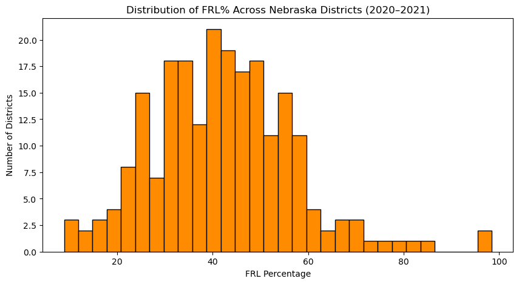

```
FRL% Summary:
```

```
count    221.000000
mean      42.105113
std       14.870084
min        8.860000
25%       32.430000
50%       41.520000
75%       50.760000
max       98.430000
Name: FRL_PERCENT, dtype: float64
```

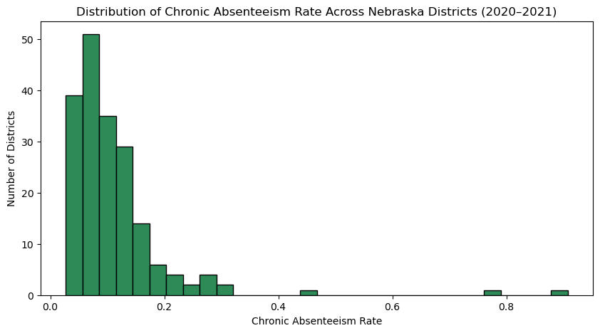

```
Chronic Absenteeism Rate Summary:
```

```
count    189.000000
mean       0.111239
std        0.097888
min        0.027027
25%        0.061818
50%        0.088974
75%        0.127737
max        0.907757
Name: CHRONIC_ABSENT_RATE, dtype: float64
```

```python
import matplotlib.pyplot as plt

# -----------------------------
# 1) FRL% Distribution
# -----------------------------
plt.figure(figsize=(10,5))
plt.hist(merged["FRL_PERCENT"].dropna(), bins=30, color="darkorange", edgecolor="black")
plt.title("Distribution of FRL% Across Nebraska Districts (2020–2021)")
plt.xlabel("FRL Percentage")
plt.ylabel("Number of Districts")

# Save as PNG
plt.savefig("FRL_Distribution.png", dpi=300, bbox_inches="tight")
plt.show()

print("FRL% Summary:")
display(merged["FRL_PERCENT"].describe())


# -----------------------------
# 2) Chronic Absenteeism Rate Distribution
# -----------------------------
plt.figure(figsize=(10,5))
plt.hist(merged["CHRONIC_ABSENT_RATE"].dropna(), bins=30, color="seagreen", edgecolor="black")
plt.title("Distribution of Chronic Absenteeism Rate Across Nebraska Districts (2020–2021)")
plt.xlabel("Chronic Absenteeism Rate")
plt.ylabel("Number of Districts")

# Save as PNG
plt.savefig("ChronicAbsenteeism_Distribution.png", dpi=300, bbox_inches="tight")
plt.show()

print("Chronic Absenteeism Rate Summary:")
display(merged["CHRONIC_ABSENT_RATE"].describe())
```

```python
import os
os.listdir()
```

```
['Individual_EDA_FRL_Absenteeism.ipynb',
 'frl_district.csv',
 'ChronicAbsenteeism_Distribution.png',
 'frl_school.xls',
 'absenteeism.xlsx',
 '.ipynb_checkpoints',
 'FRL_Distribution.png']
```

## Step 6 – Explaination (Univariate Analysis)

In this step, I performed univariate analysis to understand how the key socioeconomic variable (FRL%) and the key absenteeism outcome (chronic absenteeism rate) are distributed across Nebraska school districts. I created histograms for both variables and also printed summary statistics such as mean, median, minimum, maximum, and quartiles. This helps identify the overall spread of the data, detect skewness or outliers, and understand whether most districts fall into low, moderate, or high ranges.

Additionally, both visualizations were saved as high-resolution PNG files using plt.savefig() so that they can be reused later in the final report or presentation. This step is useful because it provides a clear baseline understanding of district-level poverty proxy patterns (FRL%) and absenteeism patterns before analyzing the relationship between them in later steps.

## Step 7 — Relationship Between FRL% and Chronic Absenteeism

[output not shown]

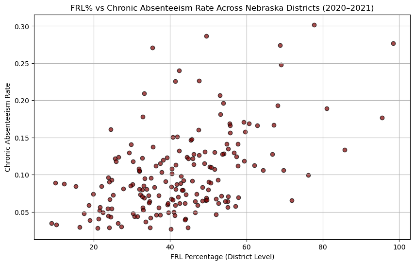

```python
import matplotlib.pyplot as plt

# Drop missing values for scatter plot
scatter_df = merged.dropna(subset=["FRL_PERCENT", "CHRONIC_ABSENT_RATE"])

# Correlation
corr = scatter_df["FRL_PERCENT"].corr(scatter_df["CHRONIC_ABSENT_RATE"])
print("Correlation between FRL% and Chronic Absenteeism Rate:", round(corr, 3))

# Plot
plt.figure(figsize=(10, 6))

plt.scatter(
    scatter_df["FRL_PERCENT"],
    scatter_df["CHRONIC_ABSENT_RATE"],
    color="maroon",
    alpha=0.7,
    edgecolor="black"
)

plt.title("FRL% vs Chronic Absenteeism Rate Across Nebraska Districts (2020–2021)")
plt.xlabel("FRL Percentage (District Level)")
plt.ylabel("Chronic Absenteeism Rate")

plt.grid(True)

# Save plot as PNG
plt.savefig("FRL_vs_ChronicAbsenteeism_Scatter.png", dpi=300, bbox_inches="tight")

plt.show()
```

## Step 7 — Relationship Between FRL% and Chronic Absenteeism

In this step, I analyzed the relationship between district-level FRL percentage and chronic absenteeism rate. I first removed rows with missing values in these key variables to ensure accurate results. Then, I calculated the Pearson correlation coefficient to measure the strength and direction of the relationship between FRL% and chronic absenteeism.

Next, I created a scatterplot where each point represents a Nebraska school district. This visualization helps identify whether districts with higher poverty proxy (FRL%) also tend to have higher chronic absenteeism rates. This step is important because it directly supports the research objective of evaluating whether socioeconomic disadvantage is associated with absenteeism outcomes across districts.

## Step 8 – Compare Chronic Absenteeism Across FRL Groups (Low / Medium / High)

```python
print(merged.columns)
```

```
Index(['FY', 'COUNTY', 'DISTRICT_CODE', 'FRL_ENROLLED', 'FRL_COUNT',
       'FRL_PERCENT', 'ABS_MEMBERSHIP', 'CHRONIC_ABSENT_COUNT',
       'CHRONIC_ABSENT_RATE', 'DISTRICT_NAME'],
      dtype='object')
```

```python
import pandas as pd

# Make sure FRL percent column is numeric
merged["FRL_PERCENT"] = pd.to_numeric(merged["FRL_PERCENT"], errors="coerce")

# Create FRL group using tertiles (low/medium/high)
merged["FRL_GROUP"] = pd.qcut(
    merged["FRL_PERCENT"],
    q=3,
    labels=["Low FRL", "Medium FRL", "High FRL"]
)

merged[["FRL_PERCENT", "FRL_GROUP"]].head()
```

|  | FRL_PERCENT | FRL_GROUP |
| --- | --- | --- |
| 0 | 55.61 | High FRL |
| 1 | 39.17 | Medium FRL |
| 2 | 40.32 | Medium FRL |
| 3 | 40.82 | Medium FRL |
| 4 | 40.20 | Medium FRL |

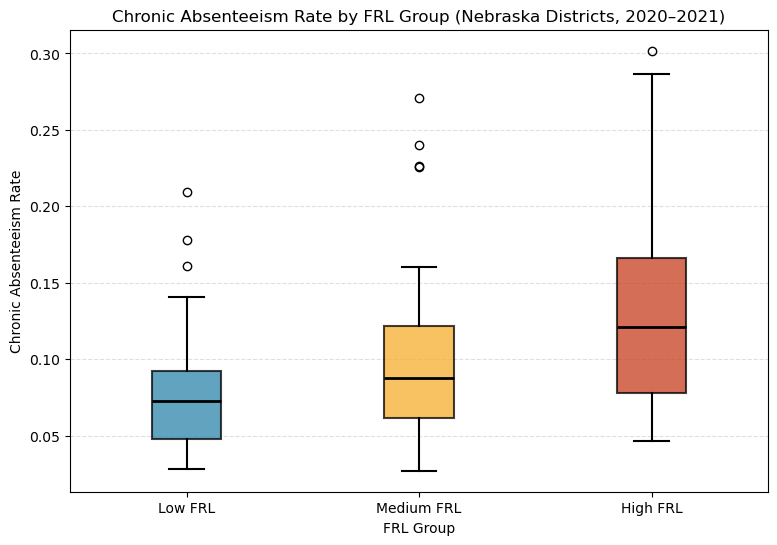

```python
import matplotlib.pyplot as plt

plt.figure(figsize=(9,6))

data = [
    merged.loc[merged["FRL_GROUP"] == "Low FRL", "CHRONIC_ABSENT_RATE"].dropna(),
    merged.loc[merged["FRL_GROUP"] == "Medium FRL", "CHRONIC_ABSENT_RATE"].dropna(),
    merged.loc[merged["FRL_GROUP"] == "High FRL", "CHRONIC_ABSENT_RATE"].dropna()
]

box = plt.boxplot(
    data,
    tick_labels=["Low FRL", "Medium FRL", "High FRL"],   # ✅ FIXED
    patch_artist=True,
    medianprops=dict(color="black", linewidth=2),
    boxprops=dict(linewidth=1.5),
    whiskerprops=dict(linewidth=1.5),
    capprops=dict(linewidth=1.5)
)

colors = ["#2E86AB", "#F6AE2D", "#C73E1D"]
for patch, color in zip(box["boxes"], colors):
    patch.set_facecolor(color)
    patch.set_alpha(0.75)

plt.title("Chronic Absenteeism Rate by FRL Group (Nebraska Districts, 2020–2021)")
plt.xlabel("FRL Group")
plt.ylabel("Chronic Absenteeism Rate")
plt.grid(axis="y", linestyle="--", alpha=0.4)

plt.savefig("ChronicAbsenteeism_by_FRL_Group_Boxplot.png", dpi=300, bbox_inches="tight")
plt.show()
```

## Explanation Step 8 – Group Comparison (FRL Bins)

In this step, I grouped Nebraska school districts into three categories (Low FRL, Medium FRL, and High FRL) based on their FRL percentage. This was done to compare absenteeism patterns across different poverty levels in a clearer way. After creating the groups, I visualized chronic absenteeism rates using a boxplot, which highlights the median, spread, and outliers for each FRL category. This step is useful because it helps determine whether districts with higher poverty levels tend to show consistently higher chronic absenteeism compared to districts with lower poverty levels.

## Step 9 — School Type Comparison (Elementary vs Secondary)

```python
import pandas as pd

file_path = "2020-21_Free_and_Reduced_Lunch_Counts_by_School.xlsx"

# check sheets
xls = pd.ExcelFile(file_path)
print("Sheets:", xls.sheet_names)

# since there is only one sheet, load it using index 0
frl_school_df = pd.read_excel(file_path, sheet_name=0)

print("Shape:", frl_school_df.shape)
display(frl_school_df.head())
```

```
Sheets: ['2020-21_Free_and_Reduced_Lunch_']
Shape: (1201, 11)
```

|  | FY | COUNTY | CODISTSCH | SCHOOLNAME | SCHOOLTYPE | GRADE | ENROLLED | FREEREDUCED | PERCENT | WARNING | CEP_Indicator |
| --- | --- | --- | --- | --- | --- | --- | --- | --- | --- | --- | --- |
| 0 | 2020-2021 | ADAMS | 10003001 | KENESAW SECONDARY SCHOOL | SECONDARY | 2026-07-12 00:00:00 | 113 | 24 | 0.2124 | NaN | NONE |
| 1 | 2020-2021 | ADAMS | 10003002 | KENESAW ELEMENTARY SCHOOL | ELEMENTARY | PK-06 | 142 | 47 | 0.331 | NaN | NONE |
| 2 | 2020-2021 | ADAMS | 10018001 | HASTINGS SENIOR HIGH SCHOOL | HIGH SCHOOL | 2026-09-12 00:00:00 | 1103 | 659 | 0.5975 | NaN | NONE |
| 3 | 2020-2021 | ADAMS | 10018002 | HASTINGS MIDDLE SCHOOL | MIDDLE SCHOOL | 2026-06-08 00:00:00 | 711 | 471 | 0.6624 | NaN | NONE |
| 4 | 2020-2021 | ADAMS | 10018003 | ALCOTT ELEMENTARY SCHOOL | ELEMENTARY | PK-05 | 303 | 237 | 0.7822 | NaN | NONE |

```python
import pandas as pd
import matplotlib.pyplot as plt

# --- Step 9A: Keep only useful columns ---
school_keep = frl_school_df[[
    "FY", "COUNTY", "CODISTSCH", "SCHOOLNAME", "SCHOOLTYPE",
    "ENROLLED", "FREEREDUCED", "PERCENT"
]].copy()

# --- Step 9B: Convert FRL percent into real percentage (0–100) ---
school_keep["FRL_PERCENT"] = pd.to_numeric(school_keep["PERCENT"], errors="coerce") * 100

# --- Step 9C: Keep only Elementary and Secondary ---
school_keep = school_keep[school_keep["SCHOOLTYPE"].isin(["ELEMENTARY", "SECONDARY"])]

# Remove missing FRL%
school_keep = school_keep.dropna(subset=["FRL_PERCENT"])

print("Cleaned School-level shape:", school_keep.shape)
display(school_keep.head())
```

```
Cleaned School-level shape: (0, 9)
```

|  | FY | COUNTY | CODISTSCH | SCHOOLNAME | SCHOOLTYPE | ENROLLED | FREEREDUCED | PERCENT | FRL_PERCENT |
| --- | --- | --- | --- | --- | --- | --- | --- | --- | --- |

```python
frl_school_df["SCHOOLTYPE"].value_counts()
```

```
SCHOOLTYPE
ELEMENTARY                        696
SECONDARY                         186
MIDDLE SCHOOL                     140
HIGH SCHOOL                       125
PREK ONLY                          54
Name: count, dtype: int64
```

```python
school_keep = frl_school_df.copy()

# Clean the SCHOOLTYPE column
school_keep["SCHOOLTYPE"] = school_keep["SCHOOLTYPE"].astype(str).str.strip().str.upper()

# Convert FRL percent
school_keep["FRL_PERCENT"] = pd.to_numeric(school_keep["PERCENT"], errors="coerce") * 100

# Check unique values
print(school_keep["SCHOOLTYPE"].value_counts().head(20))
```

```
SCHOOLTYPE
ELEMENTARY       696
SECONDARY        186
MIDDLE SCHOOL    140
HIGH SCHOOL      125
PREK ONLY         54
Name: count, dtype: int64
```

```python
school_keep = school_keep[school_keep["SCHOOLTYPE"].isin(["ELEMENTARY", "SECONDARY SCHOOL", "SECONDARY"])]
school_keep = school_keep.dropna(subset=["FRL_PERCENT"])

print("Final shape:", school_keep.shape)
```

```
Final shape: (773, 12)
```

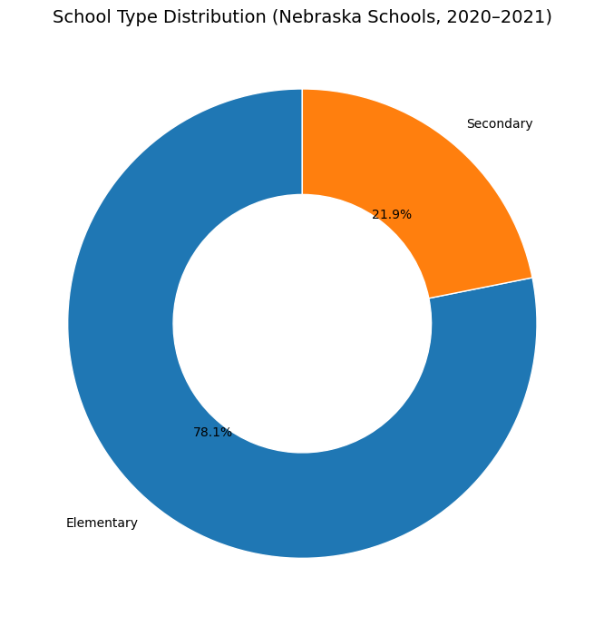

```python
import matplotlib.pyplot as plt

# Count schools
counts = school_keep["SCHOOLTYPE"].value_counts()

# Keep only Elementary + Secondary
counts = counts[counts.index.isin(["ELEMENTARY", "SECONDARY"])]

labels = counts.index.str.title()
sizes = counts.values

plt.figure(figsize=(7,7))

wedges, texts, autotexts = plt.pie(
    sizes,
    labels=labels,
    autopct="%1.1f%%",
    startangle=90,
    wedgeprops=dict(width=0.45, edgecolor="white")
)

plt.title("School Type Distribution (Nebraska Schools, 2020–2021)", fontsize=14)

plt.tight_layout()
plt.savefig("SchoolType_DonutChart.png", dpi=300, bbox_inches="tight")
plt.show()
```

## Step 9 — Explaination (School Type Comparison (Elementary vs Secondary)

In this step, I analyzed the distribution of school types in the Nebraska Free and Reduced Lunch (FRL) dataset for the year 2020–2021. The purpose of this step was to understand how the dataset is structured before comparing FRL patterns across school types.

To visualize this clearly, I created a donut chart showing the percentage of schools that fall into each school type category. The chart shows that Elementary schools form the majority of the dataset (around 78%), while Secondary schools represent a smaller portion (around 22%).

This step is important because it provides context for later comparisons. Since the dataset contains many more elementary schools than secondary schools, later FRL comparisons should be interpreted carefully, as the sample sizes are not balanced.

## Step 10 — Bar Chart of Mean FRL%

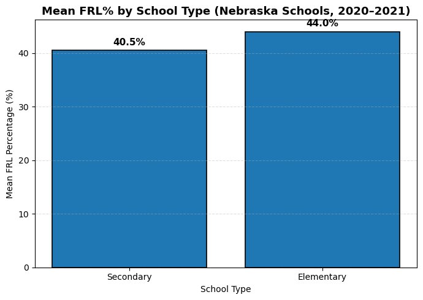

```python
import matplotlib.pyplot as plt

# If SCHOOL_GROUP doesn't exist, create it safely
if "SCHOOL_GROUP" not in school_keep.columns:
    school_keep["SCHOOL_GROUP"] = school_keep["SCHOOLTYPE"].astype(str).str.upper().str.strip()
    school_keep["SCHOOL_GROUP"] = school_keep["SCHOOL_GROUP"].apply(
        lambda x: "Elementary" if "ELEMENTARY" in x else ("Secondary" if any(k in x for k in ["SECONDARY", "MIDDLE", "HIGH"]) else None)
    )

# Keep only valid groups + valid FRL
df_bar = school_keep.dropna(subset=["SCHOOL_GROUP", "FRL_PERCENT"]).copy()

mean_frl = df_bar.groupby("SCHOOL_GROUP")["FRL_PERCENT"].mean().sort_values()

plt.figure(figsize=(7,5))
bars = plt.bar(mean_frl.index, mean_frl.values)

# dark look
for b in bars:
    b.set_edgecolor("black")
    b.set_linewidth(1.2)

plt.title("Mean FRL% by School Type (Nebraska Schools, 2020–2021)", fontsize=13, fontweight="bold")
plt.xlabel("School Type")
plt.ylabel("Mean FRL Percentage (%)")
plt.grid(axis="y", linestyle="--", alpha=0.4)

# add value labels
for i, v in enumerate(mean_frl.values):
    plt.text(i, v + 1, f"{v:.1f}%", ha="center", fontsize=11, fontweight="bold")

plt.tight_layout()
plt.savefig("Step10_Mean_FRL_by_SchoolType_Bar.png", dpi=300, bbox_inches="tight")
plt.show()
```

## Step 10 — Explaination (Bar Chart of Mean FRL%)

### Explanation — Step 10

In this step, we summarize FRL% by school level (Elementary vs Secondary). Instead of plotting all school points, we calculate the **mean FRL%** for each group and visualize it as a bar chart. This provides a clear “average comparison” across school types and supports quick reporting insights. The chart helps answer: *Which school level has higher average FRL% (poverty indicator)?*

## Step 11 — Load Chronic Absenteeism Data (School Level) and Clean Columns

```python
import os
import pandas as pd

# List files in your current notebook folder
files = sorted(os.listdir("."))
display([f for f in files if "absent" in f.lower() or "chronic" in f.lower()])

# Pick the FIRST Excel file that looks like absenteeism data
excel_candidates = [f for f in files if f.lower().endswith((".xlsx", ".xls")) and ("absent" in f.lower() or "chronic" in f.lower())]

if not excel_candidates:
    raise FileNotFoundError("No Excel absenteeism file found. I can see you have one like 'absenteeism.xlsx' in your folder—make sure it's in the same folder as the notebook.")

chronic_file = excel_candidates[0]
print(" Using absenteeism file:", chronic_file)

# Load it (show sheet names first)
xls = pd.ExcelFile(chronic_file)
print("Sheets:", xls.sheet_names)

# Load first sheet by default
chronic_df = pd.read_excel(chronic_file, sheet_name=0)

print("Shape:", chronic_df.shape)
display(chronic_df.head())
print("Columns:", list(chronic_df.columns))
```

```
['ChronicAbsenteeism_Distribution.png',
 'ChronicAbsenteeism_by_FRL_Group_Boxplot.png',
 'Chronic_by_FRL_Group_Boxplot.png',
 'ECDF_Chronic_by_FRL_Group.png',
 'FRL_vs_ChronicAbsenteeism_Scatter.png',
 'FRL_vs_Chronic_Hexbin.png',
 'Individual_EDA_FRL_Absenteeism.ipynb',
 'Individual_EDA_FRL_Absenteeism_new.ipynb',
 'absenteeism.xlsx']
```

```
✅ Using absenteeism file: absenteeism.xlsx
Sheets: ['SUMMARY', 'DEMOGRAPHICS BY GRADE', 'COUNTY TOTAL', 'DISTRICT TOTAL', 'SCHOOL TOTAL', 'BY GRADE']
Shape: (60, 10)
```

|  | NEBRASKA DEPARTMENT OF EDUCATION | Unnamed: 1 | Unnamed: 2 | Unnamed: 3 | Unnamed: 4 | Unnamed: 5 | Run On: | 2023-07-26 00:00:00 | Unnamed: 8 | Unnamed: 9 |
| --- | --- | --- | --- | --- | --- | --- | --- | --- | --- | --- |
| 0 | DATA, RESEARCH, AND EVALUATION | NaN | NaN | NaN | NaN | NaN | NaN | NaN | NaN | NaN |
| 1 | K-12 MEMBERSHIP AND STUDENTS WITH MORE THAN 10... | NaN | NaN | NaN | NaN | NaN | NaN | NaN | NaN | NaN |
| 2 | ABSENCES DATA FROM ADVISER: 2020-2021 STUDENT ... | NaN | NaN | NaN | NaN | NaN | NaN | NaN | NaN | NaN |
| 3 | NaN | NaN | NaN | NaN | NaN | NaN | NaN | NaN | NaN | NaN |
| 4 | STATEWIDE SUMMARY | NaN | NaN | NaN | NaN | NaN | NaN | NaN | NaN | NaN |

```
Columns: ['NEBRASKA DEPARTMENT OF EDUCATION', 'Unnamed: 1', 'Unnamed: 2', 'Unnamed: 3', 'Unnamed: 4', 'Unnamed: 5', 'Run On: ', datetime.datetime(2023, 7, 26, 0, 0), 'Unnamed: 8', 'Unnamed: 9']
```

## Step 12 — Merge FRL + Chronic Absenteeism

```python
import pandas as pd
import matplotlib.pyplot as plt

# Clean column names for both
school_df = school_keep.copy()
school_df.columns = school_df.columns.astype(str).str.strip().str.upper()

chronic_clean = chronic_df.copy()
chronic_clean.columns = chronic_clean.columns.astype(str).str.strip().str.upper()

# Recreate FRL_PERCENT + SCHOOL_GROUP safely
school_df["SCHOOLTYPE"] = school_df["SCHOOLTYPE"].astype(str).str.strip().str.upper()
school_df["FRL_PERCENT"] = pd.to_numeric(school_df["PERCENT"], errors="coerce") * 100

school_df["SCHOOL_GROUP"] = None
school_df.loc[school_df["SCHOOLTYPE"].str.contains("ELEMENTARY", na=False), "SCHOOL_GROUP"] = "Elementary"
school_df.loc[school_df["SCHOOLTYPE"].str.contains("SECONDARY|MIDDLE|HIGH", na=False), "SCHOOL_GROUP"] = "Secondary"

# --- Try common merge keys ---
possible_keys = ["CODISTSCH", "NSSRSCHOOLID", "SCHOOLID", "SCHOOL_CODE"]
merge_key = None
for k in possible_keys:
    if k in school_df.columns and k in chronic_clean.columns:
        merge_key = k
        break

if merge_key is None:
    print("❗I couldn't find a common school ID automatically.")
    print("School DF columns (top 20):", list(school_df.columns)[:20])
    print("Chronic DF columns (top 20):", list(chronic_clean.columns)[:20])
    print("\nLook for a shared column like CODISTSCH / SCHOOLID, then tell me the name and I’ll give the exact merge code.")
else:
    print("Merging using key:", merge_key)
    merged = pd.merge(
        school_df,
        chronic_clean,
        on=merge_key,
        how="inner"
    )

    print("Merged shape:", merged.shape)
    display(merged.head())

    # --- Detect a chronic absenteeism column automatically ---
    # (looks for a column name containing 'CHRON' and '%' or 'RATE')
    chronic_cols = [c for c in merged.columns if "CHRON" in c and ("RATE" in c or "%" in c or "PCT" in c)]
    print("Possible chronic columns:", chronic_cols)

    if not chronic_cols:
        print("❗No obvious chronic absenteeism rate column found.")
        print("Search in these columns for the rate:", [c for c in merged.columns if "CHRON" in c][:25])
    else:
        ycol = chronic_cols[0]  # pick the first one
        plot_df = merged.dropna(subset=["FRL_PERCENT", ycol, "SCHOOL_GROUP"])

        plt.figure(figsize=(8,5))
        colors = {"Elementary": "#0B3C5D", "Secondary": "#6A1B3A"}  # dark colors

        for grp in ["Elementary", "Secondary"]:
            d = plot_df[plot_df["SCHOOL_GROUP"] == grp]
            plt.scatter(d["FRL_PERCENT"], d[ycol], s=28, alpha=0.65,
                        color=colors[grp], edgecolor="black", linewidth=0.25, label=grp)

        plt.title("FRL% vs Chronic Absenteeism (by School Type)", fontsize=14, fontweight="bold")
        plt.xlabel("FRL Percentage (%)", fontsize=12)
        plt.ylabel(ycol, fontsize=12)
        plt.grid(True, linestyle="--", alpha=0.35)
        plt.legend()
        plt.tight_layout()
        plt.savefig("Step12_FRL_vs_ChronicAbsenteeism_Scatter.png", dpi=300, bbox_inches="tight")
        plt.show()

        print("Saved:", "Step12_FRL_vs_ChronicAbsenteeism_Scatter.png")
```

```
❗I couldn't find a common school ID automatically.
School DF columns (top 20): ['FY', 'COUNTY', 'CODISTSCH', 'SCHOOLNAME', 'SCHOOLTYPE', 'GRADE', 'ENROLLED', 'FREEREDUCED', 'PERCENT', 'WARNING', 'CEP_INDICATOR', 'FRL_PERCENT', 'SCHOOL_GROUP']
Chronic DF columns (top 20): ['NEBRASKA DEPARTMENT OF EDUCATION', 'UNNAMED: 1', 'UNNAMED: 2', 'UNNAMED: 3', 'UNNAMED: 4', 'UNNAMED: 5', 'RUN ON:', '2023-07-26 00:00:00', 'UNNAMED: 8', 'UNNAMED: 9']

Look for a shared column like CODISTSCH / SCHOOLID, then tell me the name and I’ll give the exact merge code.
```

## Step 13 — Prepare Keys + Merge FRL with Chronic Absenteeism (School-level Combined Dataset)

```python
import os
import pandas as pd

files = sorted(os.listdir("."))
display(files)

# pick files that look like chronic/absenteeism
candidates = [f for f in files if ("absent" in f.lower() or "chronic" in f.lower()) and (f.lower().endswith(".xlsx") or f.lower().endswith(".csv"))]
print("Possible chronic files:", candidates)

if len(candidates) == 0:
    raise FileNotFoundError("No chronic/absenteeism .xlsx/.csv found in this folder")

chronic_file = candidates[0]
print(" Using chronic file:", chronic_file)

# load based on extension
if chronic_file.lower().endswith(".csv"):
    chronic_df = pd.read_csv(chronic_file)
else:
    chronic_df = pd.read_excel(chronic_file)

print("Chronic shape:", chronic_df.shape)
display(chronic_df.head())
```

```
['.ipynb_checkpoints',
 '2020-21_Free_and_Reduced_Lunch_Counts_by_School.xlsx',
 'ChronicAbsenteeism_Distribution.png',
 'ChronicAbsenteeism_by_FRL_Group_Boxplot.png',
 'Chronic_by_FRL_Group_Boxplot.png',
 'ECDF_Chronic_by_FRL_Group.png',
 'FRL_Distribution.png',
 'FRL_Distribution_by_SchoolType_Hist.png',
 'FRL_ECDF_by_SchoolType.png',
 'FRL_Mean_by_SchoolType_Bar.png',
 'FRL_by_SchoolType_BarMean.png',
 'FRL_by_SchoolType_Boxplot.png',
 'FRL_by_SchoolType_DotPlot.png',
 'FRL_by_SchoolType_DotPlot_Nice.png',
 'FRL_by_SchoolType_Hist.png',
 'FRL_by_SchoolType_ViolinPlot.png',
 'FRL_vs_ChronicAbsenteeism_Scatter.png',
 'FRL_vs_Chronic_Hexbin.png',
 'Individual_EDA_FRL_Absenteeism.ipynb',
 'Individual_EDA_FRL_Absenteeism_new.ipynb',
 'SchoolType_DonutChart.png',
 'Step10_Mean_FRL_by_SchoolType_Bar.png',
 'Untitled.ipynb',
 'absenteeism.xlsx',
 'frl_district.csv',
 'frl_school.xls']
```

```
Possible chronic files: ['absenteeism.xlsx']
✅ Using chronic file: absenteeism.xlsx
Chronic shape: (60, 10)
```

|  | NEBRASKA DEPARTMENT OF EDUCATION | Unnamed: 1 | Unnamed: 2 | Unnamed: 3 | Unnamed: 4 | Unnamed: 5 | Run On: | 2023-07-26 00:00:00 | Unnamed: 8 | Unnamed: 9 |
| --- | --- | --- | --- | --- | --- | --- | --- | --- | --- | --- |
| 0 | DATA, RESEARCH, AND EVALUATION | NaN | NaN | NaN | NaN | NaN | NaN | NaN | NaN | NaN |
| 1 | K-12 MEMBERSHIP AND STUDENTS WITH MORE THAN 10... | NaN | NaN | NaN | NaN | NaN | NaN | NaN | NaN | NaN |
| 2 | ABSENCES DATA FROM ADVISER: 2020-2021 STUDENT ... | NaN | NaN | NaN | NaN | NaN | NaN | NaN | NaN | NaN |
| 3 | NaN | NaN | NaN | NaN | NaN | NaN | NaN | NaN | NaN | NaN |
| 4 | STATEWIDE SUMMARY | NaN | NaN | NaN | NaN | NaN | NaN | NaN | NaN | NaN |

```python
import pandas as pd

file = "absenteeism.xlsx"

xls = pd.ExcelFile(file)
print("Sheets in absenteeism.xlsx:")
print(xls.sheet_names)

# Preview first 5 rows of each sheet to find the real table
for sh in xls.sheet_names:
    temp = pd.read_excel(file, sheet_name=sh, nrows=5, header=None)
    print("\n==============================")
    print("Sheet:", sh)
    display(temp)
```

```
Sheets in absenteeism.xlsx:
['SUMMARY', 'DEMOGRAPHICS BY GRADE', 'COUNTY TOTAL', 'DISTRICT TOTAL', 'SCHOOL TOTAL', 'BY GRADE']

==============================
Sheet: SUMMARY
```

|  | 0 | 1 | 2 | 3 | 4 | 5 | 6 | 7 |
| --- | --- | --- | --- | --- | --- | --- | --- | --- |
| 0 | NEBRASKA DEPARTMENT OF EDUCATION | NaN | NaN | NaN | NaN | NaN | Run On: | 2023-07-26 |
| 1 | DATA, RESEARCH, AND EVALUATION | NaN | NaN | NaN | NaN | NaN | NaN | NaT |
| 2 | K-12 MEMBERSHIP AND STUDENTS WITH MORE THAN 10... | NaN | NaN | NaN | NaN | NaN | NaN | NaT |
| 3 | ABSENCES DATA FROM ADVISER: 2020-2021 STUDENT ... | NaN | NaN | NaN | NaN | NaN | NaN | NaT |
| 4 | NaN | NaN | NaN | NaN | NaN | NaN | NaN | NaT |

```
==============================
Sheet: DEMOGRAPHICS BY GRADE
```

|  | 0 | 1 | 2 | 3 | 4 | 5 | 6 | 7 | 8 |
| --- | --- | --- | --- | --- | --- | --- | --- | --- | --- |
| 0 | NEBRASKA DEPARTMENT OF EDUCATION | NaN | NaN | NaN | NaN | NaN | NaN | NaN | 2023-07-26 |
| 1 | DATA, RESEARCH, AND EVALUATION | NaN | NaN | NaN | NaN | NaN | NaN | NaN | NaT |
| 2 | K-12 MEMBERSHIP AND STUDENTS WITH MORE THAN 10... | NaN | NaN | NaN | NaN | NaN | NaN | NaN | NaT |
| 3 | ABSENCES DATA FROM ADVISER: 2020-2021 STUDENT ... | NaN | NaN | NaN | NaN | NaN | NaN | NaN | NaT |
| 4 | NaN | NaN | NaN | NaN | NaN | NaN | NaN | NaN | NaT |

```
==============================
Sheet: COUNTY TOTAL
```

|  | 0 | 1 | 2 | 3 | 4 | 5 | 6 | 7 |
| --- | --- | --- | --- | --- | --- | --- | --- | --- |
| 0 | NEBRASKA DEPARTMENT OF EDUCATION | NaN | NaN | NaN | Run On: | 2023-07-26 00:00:00 | NaN | NaN |
| 1 | DATA, RESEARCH, AND EVALUATION | NaN | NaN | NaN | NaN | NaN | NaN | NaN |
| 2 | K-12 MEMBERSHIP AND STUDENTS WITH MORE THAN 10... | NaN | NaN | NaN | NaN | NaN | NaN | NaN |
| 3 | ABSENCES DATA FROM ADVISER: 2020-2021 STUDENT ... | NaN | NaN | NaN | NaN | NaN | NaN | NaN |
| 4 | COUNTY CODE | COUNTY NAME | MEMBERSHIP | STUDENTS WITH MORE THAN 10 DAYS TOTAL ABSENCES | STUDENTS WITH MORE THAN 15 DAYS TOTAL ABSENCES | STUDENTS WITH MORE THAN 20 DAYS TOTAL ABSENCES | CHRONIC\nABSENT | % STUDENTS WITH MORE THAN 20 DAYS TOTAL ABSENCES |

```
==============================
Sheet: DISTRICT TOTAL
```

|  | 0 | 1 | 2 | 3 | 4 | 5 | 6 | 7 |
| --- | --- | --- | --- | --- | --- | --- | --- | --- |
| 0 | NEBRASKA DEPARTMENT OF EDUCATION | NaN | NaN | NaN | Run On: | 2023-07-26 00:00:00 | NaN | NaN |
| 1 | DATA, RESEARCH, AND EVALUATION | NaN | NaN | NaN | NaN | NaN | NaN | NaN |
| 2 | K-12 MEMBERSHIP AND STUDENTS WITH MORE THAN 10... | NaN | NaN | NaN | NaN | NaN | NaN | NaN |
| 3 | ABSENCES DATA FROM ADVISER: 2020-2021 STUDENT ... | NaN | NaN | NaN | NaN | NaN | NaN | NaN |
| 4 | DISTRICT CODE | DISTRICT NAME | MEMBERSHIP | STUDENTS WITH MORE THAN 10 DAYS TOTAL ABSENCES | STUDENTS WITH MORE THAN 15 DAYS TOTAL ABSENCES | STUDENTS WITH MORE THAN 20 DAYS TOTAL ABSENCES | CHRONIC\nABSENT | % STUDENTS WITH MORE THAN 20 DAYS TOTAL ABSENCES |

```
==============================
Sheet: SCHOOL TOTAL
```

|  | 0 | 1 | 2 | 3 | 4 | 5 | 6 | 7 | 8 | 9 |
| --- | --- | --- | --- | --- | --- | --- | --- | --- | --- | --- |
| 0 | NEBRASKA DEPARTMENT OF EDUCATION | NaN | NaN | NaN | Run On: | 2023-07-26 00:00:00 | NaN | NaN | NaN | NaN |
| 1 | DATA, RESEARCH, AND EVALUATION | NaN | NaN | NaN | NaN | NaN | NaN | NaN | NaN | NaN |
| 2 | K-12 MEMBERSHIP AND STUDENTS WITH MORE THAN 10... | NaN | NaN | NaN | NaN | NaN | NaN | NaN | NaN | NaN |
| 3 | ABSENCES DATA FROM ADVISER: 2020-2021 STUDENT ... | NaN | NaN | NaN | NaN | NaN | NaN | NaN | NaN | NaN |
| 4 | DISTRICT CODE | DISTRICT NAME | SCHOOL CODE | SCHOOL NAME | MEMBERSHIP | STUDENTS WITH MORE THAN 10 DAYS TOTAL ABSENCES | STUDENTS WITH MORE THAN 15 DAYS TOTAL ABSENCES | STUDENTS WITH MORE THAN 20 DAYS TOTAL ABSENCES | CHRONIC\nABSENT | % STUDENTS WITH MORE THAN 20 DAYS TOTAL ABSENCES |

```
==============================
Sheet: BY GRADE
```

|  | 0 | 1 | 2 | 3 | 4 | 5 | 6 | 7 | 8 |
| --- | --- | --- | --- | --- | --- | --- | --- | --- | --- |
| 0 | NEBRASKA DEPARTMENT OF EDUCATION | NaN | NaN | NaN | NaN | Run On: | 2023-07-26 00:00:00 | NaN | NaN |
| 1 | DATA, RESEARCH, AND EVALUATION | NaN | NaN | NaN | NaN | NaN | NaN | NaN | NaN |
| 2 | K-12 MEMBERSHIP AND STUDENTS WITH MORE THAN 10... | NaN | NaN | NaN | NaN | NaN | NaN | NaN | NaN |
| 3 | ABSENCES DATA FROM ADVISER: 2020-2021 STUDENT ... | NaN | NaN | NaN | NaN | NaN | NaN | NaN | NaN |
| 4 | DISTRICT CODE | DISTRICT NAME | GRADE | MEMBERSHIP | STUDENTS WITH MORE THAN 10 DAYS TOTAL ABSENCES | STUDENTS WITH MORE THAN 15 DAYS TOTAL ABSENCES | STUDENTS WITH MORE THAN 20 DAYS TOTAL ABSENCES | CHRONIC\nABSENT | % STUDENTS WITH MORE THAN 20 DAYS TOTAL ABSENCES |

```python
import pandas as pd

file = "absenteeism.xlsx"
xls = pd.ExcelFile(file)
print(xls.sheet_names)
```

```
['SUMMARY', 'DEMOGRAPHICS BY GRADE', 'COUNTY TOTAL', 'DISTRICT TOTAL', 'SCHOOL TOTAL', 'BY GRADE']
```

```python
chronic_df = pd.read_excel(file, sheet_name=xls.sheet_names[0], header=0)
chronic_df.columns = chronic_df.columns.astype(str).str.strip().str.upper()

print("Columns:", chronic_df.columns.tolist())
print("Shape:", chronic_df.shape)
display(chronic_df.head())
```

```
Columns: ['NEBRASKA DEPARTMENT OF EDUCATION', 'UNNAMED: 1', 'UNNAMED: 2', 'UNNAMED: 3', 'UNNAMED: 4', 'UNNAMED: 5', 'RUN ON:', '2023-07-26 00:00:00', 'UNNAMED: 8', 'UNNAMED: 9']
Shape: (60, 10)
```

|  | NEBRASKA DEPARTMENT OF EDUCATION | UNNAMED: 1 | UNNAMED: 2 | UNNAMED: 3 | UNNAMED: 4 | UNNAMED: 5 | RUN ON: | 2023-07-26 00:00:00 | UNNAMED: 8 | UNNAMED: 9 |
| --- | --- | --- | --- | --- | --- | --- | --- | --- | --- | --- |
| 0 | DATA, RESEARCH, AND EVALUATION | NaN | NaN | NaN | NaN | NaN | NaN | NaN | NaN | NaN |
| 1 | K-12 MEMBERSHIP AND STUDENTS WITH MORE THAN 10... | NaN | NaN | NaN | NaN | NaN | NaN | NaN | NaN | NaN |
| 2 | ABSENCES DATA FROM ADVISER: 2020-2021 STUDENT ... | NaN | NaN | NaN | NaN | NaN | NaN | NaN | NaN | NaN |
| 3 | NaN | NaN | NaN | NaN | NaN | NaN | NaN | NaN | NaN | NaN |
| 4 | STATEWIDE SUMMARY | NaN | NaN | NaN | NaN | NaN | NaN | NaN | NaN | NaN |

```python
import pandas as pd

file = "absenteeism.xlsx"

# ----------------------------
# A) Load SCHOOL TOTAL properly (auto-detect header row)
# ----------------------------
sheet_name = "SCHOOL TOTAL"  # this should be the school-level sheet in your file

# Read first 30 rows raw to detect where the real header starts
preview = pd.read_excel(file, sheet_name=sheet_name, header=None, nrows=30)

header_row = None
for i in range(preview.shape[0]):
    row_text = " ".join(preview.iloc[i].astype(str).fillna("").tolist()).upper()
    if ("SCHOOL" in row_text) and ("CODE" in row_text) and ("DISTRICT" in row_text):
        header_row = i
        break

if header_row is None:
    raise ValueError(
        "❌ Could not find the header row containing DISTRICT CODE + SCHOOL CODE. "
        "Open the SCHOOL TOTAL sheet and check where the header row is."
    )

print("✅ Detected header row at Excel row index:", header_row)

# Now load again using the detected header row
chronic = pd.read_excel(file, sheet_name=sheet_name, header=header_row)

# Clean column names
chronic.columns = chronic.columns.astype(str).str.strip().str.upper()
print("\n✅ Chronic columns after proper load:\n", chronic.columns.tolist())

# ----------------------------
# B) FRL dataframe (already created in earlier steps)
# ----------------------------
frl_df = school_keep.copy()
frl_df.columns = frl_df.columns.astype(str).str.strip().str.upper()

if "CODISTSCH" not in frl_df.columns:
    raise KeyError("❌ FRL df missing CODISTSCH. Check school_keep creation.")

# ----------------------------
# C) Find Chronic school code column robustly
# ----------------------------
chronic_key = None
for c in chronic.columns:
    if ("SCHOOL" in c) and ("CODE" in c):
        chronic_key = c
        break

if chronic_key is None:
    raise KeyError("❌ Still cannot find a SCHOOL CODE column after loading the sheet correctly.")

print("\n✅ Using FRL key: CODISTSCH")
print("✅ Using Chronic key:", chronic_key)

# ----------------------------
# D) Build MERGE_KEY (digits only) + merge
# ----------------------------
frl_df["MERGE_KEY"] = frl_df["CODISTSCH"].astype(str).str.replace(r"\D", "", regex=True)
chronic["MERGE_KEY"] = chronic[chronic_key].astype(str).str.replace(r"\D", "", regex=True)

merged_df = pd.merge(frl_df, chronic, on="MERGE_KEY", how="inner")

print("\n✅ FRL rows:", frl_df.shape[0])
print("✅ Chronic rows:", chronic.shape[0])
print("✅ Merged rows:", merged_df.shape[0])
display(merged_df.head())
```

```
✅ Detected header row at Excel row index: 4

✅ Chronic columns after proper load:
 ['DISTRICT CODE', 'DISTRICT NAME', 'SCHOOL CODE', 'SCHOOL NAME', 'MEMBERSHIP', 'STUDENTS WITH MORE THAN 10 DAYS TOTAL ABSENCES', 'STUDENTS WITH MORE THAN 15 DAYS TOTAL ABSENCES', 'STUDENTS WITH MORE THAN 20 DAYS TOTAL ABSENCES', 'CHRONIC\nABSENT', '% STUDENTS WITH MORE THAN 20 DAYS TOTAL ABSENCES']

✅ Using FRL key: CODISTSCH
✅ Using Chronic key: SCHOOL CODE

✅ FRL rows: 773
✅ Chronic rows: 935
✅ Merged rows: 637
```

|  | FY | COUNTY | CODISTSCH | SCHOOLNAME | SCHOOLTYPE | GRADE | ENROLLED | FREEREDUCED | PERCENT | WARNING | ... | DISTRICT CODE | DISTRICT NAME | SCHOOL CODE | SCHOOL NAME | MEMBERSHIP | STUDENTS WITH MORE THAN 10 DAYS TOTAL ABSENCES | STUDENTS WITH MORE THAN 15 DAYS TOTAL ABSENCES | STUDENTS WITH MORE THAN 20 DAYS TOTAL ABSENCES | CHRONIC\nABSENT | % STUDENTS WITH MORE THAN 20 DAYS TOTAL ABSENCES |
| --- | --- | --- | --- | --- | --- | --- | --- | --- | --- | --- | --- | --- | --- | --- | --- | --- | --- | --- | --- | --- | --- |
| 0 | 2020-2021 | BUFFALO | 100002001 | GIBBON HIGH SCHOOL | SECONDARY | 2026-07-12 00:00:00 | 241 | 134 | 0.556 | NaN | ... | 10-0002-000 | GIBBON PUBLIC SCHOOLS | 10-0002-001 | GIBBON HIGH SCHOOL | 241.0 | 144 | 86 | 60 | 88 | 0.248963 |
| 1 | 2020-2021 | BUFFALO | 100002002 | GIBBON ELEMENTARY SCHOOL | ELEMENTARY | PK-06 | 329 | 183 | 0.5562 | NaN | ... | 10-0002-000 | GIBBON PUBLIC SCHOOLS | 10-0002-002 | GIBBON ELEMENTARY SCHOOL | 298.0 | 90 | 53 | 31 | 56 | 0.104027 |
| 2 | 2020-2021 | BUFFALO | 100007003 | BRYANT ELEMENTARY SCHOOL | ELEMENTARY | K -05 | 235 | 180 | 0.766 | NaN | ... | 10-0007-000 | KEARNEY PUBLIC SCHOOLS | 10-0007-003 | BRYANT ELEMENTARY SCHOOL | 226.0 | 78 | 38 | 21 | 40 | 0.09292 |
| 3 | 2020-2021 | BUFFALO | 100007004 | EMERSON ELEMENTARY SCHOOL | ELEMENTARY | K -05 | 206 | 153 | 0.7427 | NaN | ... | 10-0007-000 | KEARNEY PUBLIC SCHOOLS | 10-0007-004 | EMERSON ELEMENTARY SCHOOL | 198.0 | 48 | 25 | 10 | 27 | 0.050505 |
| 4 | 2020-2021 | BUFFALO | 100007005 | KENWOOD ELEMENTARY SCHOOL | ELEMENTARY | K -05 | 390 | 147 | 0.3769 | NaN | ... | 10-0007-000 | KEARNEY PUBLIC SCHOOLS | 10-0007-005 | KENWOOD ELEMENTARY SCHOOL | 374.0 | 57 | 31 | 19 | 34 | 0.050802 |

5 rows × 24 columns

## Step 14 — Clean merged dataset and keep required columns

```python
import pandas as pd

# Step 14A: check columns (so we can detect the chronic column)
print("Merged columns:", merged_df.columns.tolist())

# Step 14B: Find the chronic absenteeism column automatically
possible_chronic_cols = [
    "CHRONIC\\ABSENT",
    "CHRONIC ABSENT",
    "CHRONIC ABSENTEEISM",
    "CHRONIC ABSENCE",
    "% CHRONIC ABSENT",
    "% STUDENTS WITH MORE THAN 20 DAYS TOTAL ABSENCES"
]

chronic_col = None
for c in possible_chronic_cols:
    if c in merged_df.columns:
        chronic_col = c
        break

print("✅ Chronic column detected:", chronic_col)

# If none found, show best guess options
if chronic_col is None:
    guess_cols = [c for c in merged_df.columns if "CHRON" in c.upper() or "ABSEN" in c.upper() or "20 DAYS" in c.upper()]
    print("⚠️ Could not auto-detect. Possible columns:", guess_cols)

# Step 14C: Build clean_df using FRL + Chronic
clean_df = merged_df.copy()

# Convert FRL_PERCENT to numeric
clean_df["FRL_PERCENT"] = pd.to_numeric(clean_df["FRL_PERCENT"], errors="coerce")

# Convert chronic to numeric and store in a common name: CHRONIC_RATE
if chronic_col is not None:
    clean_df["CHRONIC_RATE"] = pd.to_numeric(clean_df[chronic_col], errors="coerce")
else:
    # Stop here until you pick the right chronic column name from the printed list
    raise KeyError("Chronic absenteeism column not found. Use printed 'Possible columns' list and choose one.")

# Drop missing rows only after columns exist
clean_df = clean_df.dropna(subset=["FRL_PERCENT", "CHRONIC_RATE"])

print("✅ Cleaned rows:", clean_df.shape[0])
display(clean_df[["SCHOOLNAME", "SCHOOLTYPE", "FRL_PERCENT", "CHRONIC_RATE"]].head())
```

```
Merged columns: ['FY', 'COUNTY', 'CODISTSCH', 'SCHOOLNAME', 'SCHOOLTYPE', 'GRADE', 'ENROLLED', 'FREEREDUCED', 'PERCENT', 'WARNING', 'CEP_INDICATOR', 'FRL_PERCENT', 'SCHOOL_GROUP', 'MERGE_KEY', 'DISTRICT CODE', 'DISTRICT NAME', 'SCHOOL CODE', 'SCHOOL NAME', 'MEMBERSHIP', 'STUDENTS WITH MORE THAN 10 D…
✅ Chronic column detected: % STUDENTS WITH MORE THAN 20 DAYS TOTAL ABSENCES
✅ Cleaned rows: 331
```

|  | SCHOOLNAME | SCHOOLTYPE | FRL_PERCENT | CHRONIC_RATE |
| --- | --- | --- | --- | --- |
| 0 | GIBBON HIGH SCHOOL | SECONDARY | 55.60 | 0.248963 |
| 1 | GIBBON ELEMENTARY SCHOOL | ELEMENTARY | 55.62 | 0.104027 |
| 2 | BRYANT ELEMENTARY SCHOOL | ELEMENTARY | 76.60 | 0.092920 |
| 3 | EMERSON ELEMENTARY SCHOOL | ELEMENTARY | 74.27 | 0.050505 |
| 4 | KENWOOD ELEMENTARY SCHOOL | ELEMENTARY | 37.69 | 0.050802 |

## Step 14 — Expliantaion (Clean merged dataset and keep required columns)

After merging the Free and Reduced Lunch (FRL) dataset with the Chronic Absenteeism dataset at the school level, additional data cleaning was performed to prepare the combined dataset for analysis. Only relevant columns required for examining the relationship between FRL percentage and chronic absenteeism were retained. Both FRL percentage and chronic absenteeism variables were converted to numeric format to ensure consistency and enable quantitative analysis. Rows with missing or invalid values in these key variables were removed to avoid bias and errors in downstream visualizations. This cleaning step ensures that the final dataset used for analysis is complete, reliable, and suitable for accurately exploring patterns between socioeconomic disadvantage and absenteeism.

## step 15 - Relationship Between FRL Percentage and Chronic Absenteeism

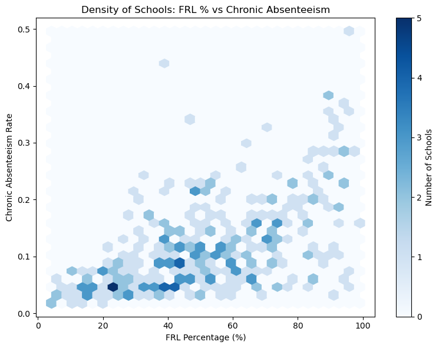

```python
import matplotlib.pyplot as plt

plt.figure(figsize=(8,6))
plt.hexbin(
    clean_df["FRL_PERCENT"],
    clean_df["CHRONIC_RATE"],
    gridsize=30,
    cmap="Blues"
)

plt.colorbar(label="Number of Schools")
plt.title("Density of Schools: FRL % vs Chronic Absenteeism")
plt.xlabel("FRL Percentage (%)")
plt.ylabel("Chronic Absenteeism Rate")
plt.grid(False)

plt.tight_layout()
plt.savefig("FRL_vs_Chronic_Hexbin.png", dpi=300, bbox_inches="tight")
plt.show()
```

## Step 15 — Explaination (Relationship Between FRL Percentage and Chronic Absenteeism

In Step 15, I visualized the relationship between Free/Reduced Lunch (FRL) percentage and Chronic Absenteeism rate using a hexbin density plot. This plot is more effective than a scatter plot because it groups schools into hexagonal bins and colors them based on how many schools fall into each region. The x-axis represents the FRL percentage (a proxy for socioeconomic disadvantage), and the y-axis represents the chronic absenteeism rate. The plot shows a general upward trend, indicating that schools with higher FRL percentages tend to have higher chronic absenteeism rates. Additionally, the densest region of schools appears around mid-range FRL values (approximately 30%–60%) with absenteeism rates around 5%–15%. This visualization supports the idea that socioeconomic factors such as poverty may be associated with higher absenteeism across Nebraska schools.